# MachineLearningPredictionAssignment

AC

6/19/2021

## Background

Using devices such as Jawbone Up, Nike FuelBand, and Fitbit it is now possible to collect a large amount of data about personal activity relatively inexpensively. These type of devices are part of the quantified self movement – a group of enthusiasts who take measurements about themselves regularly to improve their health, to find patterns in their behavior, or because they are tech geeks. One thing that people regularly do is quantify how much of a particular activity they do, but they rarely quantify how well they do it. In this project, your goal will be to use data from accelerometers on the belt, forearm, arm, and dumbell of 6 participants. They were asked to perform barbell lifts correctly and incorrectly in 5 different ways. More information is available from the website here: http://groupware.les.inf.puc-rio.br/har (see the section on the Weight Lifting Exercise Dataset).

# Loading, cleaning and partitioning the data

```r
##Loading the necessary libraries
library(caret)
```

```r
library(rpart)
library(rpart.plot)
library(randomForest)
library(rattle)
library(corrplot)
##Download the data
training <- read.csv("https://d396qusza40orc.cloudfront.net/predmachlearn/pml-training.csv",
                     na.strings=c("NA","#DIV/0!", ""))

test <- read.csv("https://d396qusza40orc.cloudfront.net/predmachlearn/pml-testing.csv",
                 na.strings=c("NA","#DIV/0!", ""))

#removing the first 5 variables as these are not important for the prediction
trainingc <- training[,-c(1:5)]
testc <- test [,-c(1:5)]
dim (trainingc)
```

```
## [1] 19622   155
```

```r
#remove columns that only have NA's
trainingc <- trainingc[, colSums(is.na(trainingc)) == 0]
testc <- testc[, colSums(is.na(testc)) == 0]

#remove near zero variance columns

NZV <- nearZeroVar(trainingc)
trainingc <- trainingc[,-NZV]
testc <- testc[,-NZV]

## partitioning
set.seed(555)
inTrain  <- createDataPartition(trainingc$classe, p = 0.6, list = FALSE)
trainp    <- trainingc[inTrain, ]
testingp     <- trainingc[-inTrain, ]
```

## Correlation Analysis

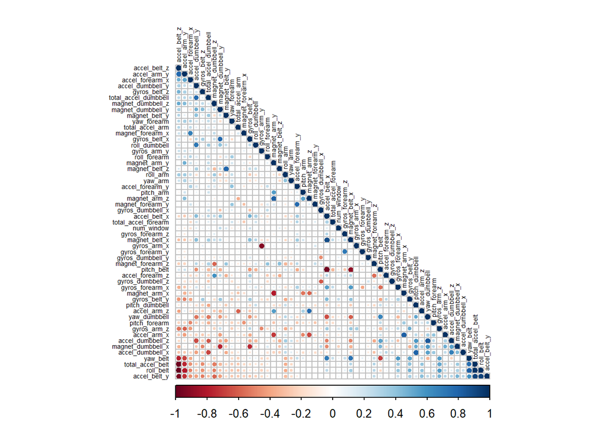

```r
M<-cor(trainp[,-54])
corrplot(M, order = "FPC", method="circle", type = "lower", tl.cex = 0.45,
         tl.col = rgb(0, 0, 0))
```

This analalysis allows to highlight the most correlated variables in the dataset, some appear to show a positive correlation (blue) others a negative correlation (red). However, the correlation between most variabls is poor. On the next step when prediction models will be evaluated all variables will be considered.

## Prediction Model Building

Three different model algorithms will be explored, and the one with the best out-of-sample accuracy will be selected for predicting the class of the testc dataset.

Decision tree with CART (dt) Stochastic gradient boosting trees (gbm) Random forest decision trees (rf)

# decision tree model

```r
modelDT  <- rpart(classe ~ ., data = trainp, method="class")
```

# Generalized Boosted Model (GBM)

```r
modelBM <- train(classe ~.,
                data = trainp,
                method = "gbm",
                trControl = trainControl(method="repeatedcv",
                                           number = 5,repeats = 1),
                                    verbose = FALSE)
```

# random forest model

```r
modelRF  <- train( classe ~.,
                   data = trainp,
                   method = "rf",
                   trControl = trainControl(method="cv",number=3) )
```

# Prediction DT

```r
predDT <- predict(modelDT, newdata = testingp, type="class")
confmatrixDT <- confusionMatrix(predDT, as.factor(testingp$classe))
print(confmatrixDT)
```

```
## Confusion Matrix and Statistics
##
##           Reference
## Prediction    A    B    C    D    E
##          A 1971  211   21   69   78
##          B   64  920   95  109  175
##          C   26  101 1104  189  126
##          D  145  247  112  863  193
##          E   26   39   36   56  870
##
## Overall Statistics
##
##                Accuracy : 0.7301
##                  95% CI : (0.7201, 0.7399)
##     No Information Rate : 0.2845
##     P-Value [Acc > NIR] : < 2.2e-16
##
##                   Kappa : 0.6584
##
##  Mcnemar's Test P-Value : < 2.2e-16
##
## Statistics by Class:
##
##                      Class: A Class: B Class: C Class: D Class: E
## Sensitivity            0.8831   0.6061   0.8070   0.6711   0.6033
## Specificity            0.9325   0.9300   0.9318   0.8938   0.9755
## Pos Pred Value         0.8387   0.6750   0.7141   0.5532   0.8471
## Neg Pred Value         0.9525   0.9078   0.9581   0.9327   0.9161
## Prevalence             0.2845   0.1935   0.1744   0.1639   0.1838
## Detection Rate         0.2512   0.1173   0.1407   0.1100   0.1109
## Detection Prevalence   0.2995   0.1737   0.1970   0.1988   0.1309
## Balanced Accuracy      0.9078   0.7680   0.8694   0.7824   0.7894
```

```r
head(predDT)
```

```
##  9 10 13 14 16 17
##  A  A  A  A  A  A
## Levels: A B C D E
```

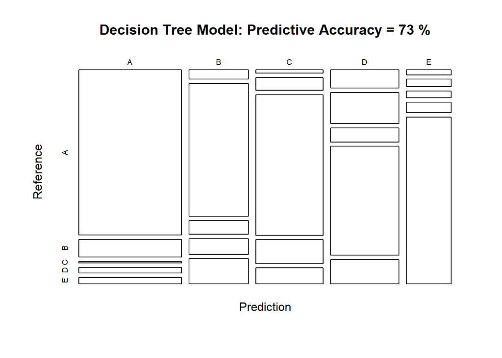

```r
#Plot the predictive accuracy of the decision tree model.

plot(confmatrixDT$table, col = confmatrixDT$byClass,
     main = paste("Decision Tree Model: Predictive Accuracy =",
                  round(confmatrixDT$overall['Accuracy']*100, 1), "%"))
```

The predictive accuracy of the decision tree model is ~73%.

## Model Assessment (accuracy/Out of sample error using the partitioned data)

# Prediction RF

```r
predRF <- predict(modelRF, testingp)
confmatrixrf <- confusionMatrix(predRF, as.factor(testingp$classe))
print(confmatrixrf)
```

```
## Confusion Matrix and Statistics
##
##           Reference
## Prediction    A    B    C    D    E
##          A 2231    2    0    0    0
##          B    0 1514    4    0    3
##          C    0    2 1364    4    0
##          D    0    0    0 1282    2
##          E    1    0    0    0 1437
##
## Overall Statistics
##
##                Accuracy : 0.9977
##                  95% CI : (0.9964, 0.9986)
##     No Information Rate : 0.2845
##     P-Value [Acc > NIR] : < 2.2e-16
##
##                   Kappa : 0.9971
##
##  Mcnemar's Test P-Value : NA
##
## Statistics by Class:
##
##                      Class: A Class: B Class: C Class: D Class: E
## Sensitivity            0.9996   0.9974   0.9971   0.9969   0.9965
## Specificity            0.9996   0.9989   0.9991   0.9997   0.9998
## Pos Pred Value         0.9991   0.9954   0.9956   0.9984   0.9993
## Neg Pred Value         0.9998   0.9994   0.9994   0.9994   0.9992
## Prevalence             0.2845   0.1935   0.1744   0.1639   0.1838
## Detection Rate         0.2843   0.1930   0.1738   0.1634   0.1832
## Detection Prevalence   0.2846   0.1939   0.1746   0.1637   0.1833
## Balanced Accuracy      0.9996   0.9981   0.9981   0.9983   0.9982
```

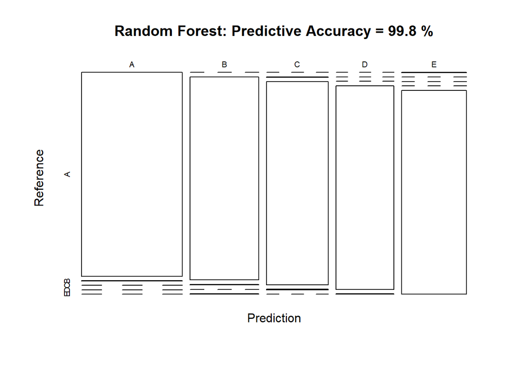

```r
#Plot the predictive accuracy of the random forest model.

plot(confmatrixrf$table, col = confmatrixrf$byClass,
     main = paste("Random Forest: Predictive Accuracy =",
                  round(confmatrixrf$overall['Accuracy']*100, 1), "%"))
```

# Prediction GBM

```r
predgbm <- predict(modelBM, testingp)
confmatrixgbm <- confusionMatrix(predgbm, as.factor(testingp$classe))
print(confmatrixgbm)
```

```
## Confusion Matrix and Statistics
##
##           Reference
## Prediction    A    B    C    D    E
##          A 2223    6    0    0    0
##          B    9 1491   23   12    4
##          C    0   19 1338   18    0
##          D    0    2    5 1255    5
##          E    0    0    2    1 1433
##
## Overall Statistics
##
##                Accuracy : 0.9865
##                  95% CI : (0.9837, 0.9889)
##     No Information Rate : 0.2845
##     P-Value [Acc > NIR] : < 2.2e-16
##
##                   Kappa : 0.9829
##
##  Mcnemar's Test P-Value : NA
##
## Statistics by Class:
##
##                      Class: A Class: B Class: C Class: D Class: E
## Sensitivity            0.9960   0.9822   0.9781   0.9759   0.9938
## Specificity            0.9989   0.9924   0.9943   0.9982   0.9995
## Pos Pred Value         0.9973   0.9688   0.9731   0.9905   0.9979
## Neg Pred Value         0.9984   0.9957   0.9954   0.9953   0.9986
## Prevalence             0.2845   0.1935   0.1744   0.1639   0.1838
## Detection Rate         0.2833   0.1900   0.1705   0.1600   0.1826
## Detection Prevalence   0.2841   0.1962   0.1752   0.1615   0.1830
## Balanced Accuracy      0.9974   0.9873   0.9862   0.9870   0.9966
```

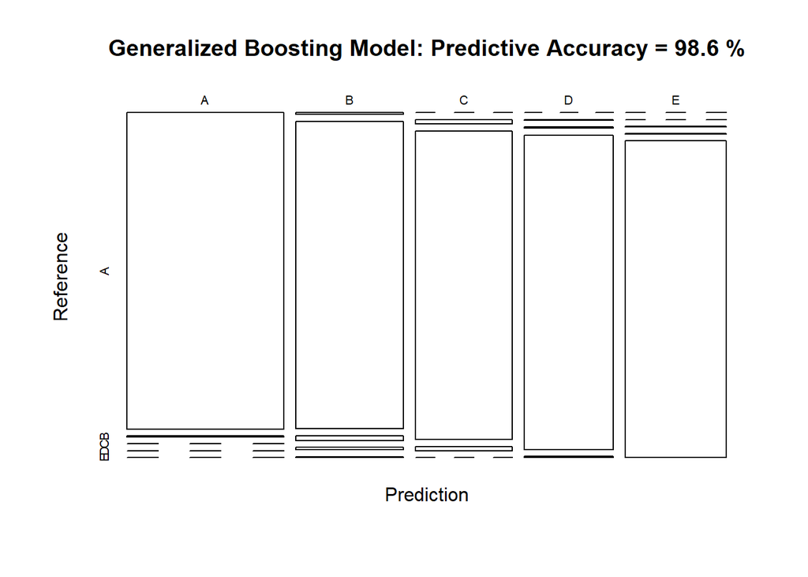

```r
#Plot the predictive accuracy of the generalized boosted model.

plot(confmatrixgbm$table, col = confmatrixDT$byClass,
     main = paste("Generalized Boosting Model: Predictive Accuracy =",
                  round(confmatrixgbm$overall['Accuracy']*100, 1), "%"))
```

The predictive accuracy of the GBM is relatively high at 98.6 %.

## Results

When comparing the 3 models, the GBM and the RF out perform the DT with the best accuracy and out of sample errors, with RF perfomring better than the GBM however the performance between these last two models was a closer. Using the model with the best accuracy, the random forest model, on the test data set (testc).

```r
predTesting <- predict(modelRF, newdata = testc)
print(predTesting)
```

```
##  [1] B A B A A E D B A A B C B A E E A B B B
## Levels: A B C D E
```